# DV4

Author

Wayne Frederick II

## Question 1

```r
library(tidyverse)
#| message: false
# Read in the data
tv_ratings <- read_csv("https://raw.githubusercontent.com/vaiseys/dav-course/main/Data/tv_ratings.csv")
# Glimpse the data
glimpse(tv_ratings)
```

```
Rows: 2,266
Columns: 7
$ titleId      <chr> "tt2879552", "tt3148266", "tt3148266", "tt3148266", "tt31…
$ seasonNumber <dbl> 1, 1, 2, 3, 4, 1, 2, 1, 2, 3, 4, 5, 6, 7, 8, 1, 1, 1, 1, …
$ title        <chr> "11.22.63", "12 Monkeys", "12 Monkeys", "12 Monkeys", "12…
$ date         <date> 2016-03-10, 2015-02-27, 2016-05-30, 2017-05-19, 2018-06-…
$ av_rating    <dbl> 8.4890, 8.3407, 8.8196, 9.0369, 9.1363, 8.4370, 7.5089, 8…
$ share        <dbl> 0.51, 0.46, 0.25, 0.19, 0.38, 2.38, 2.19, 6.67, 7.13, 5.8…
$ genres       <chr> "Drama,Mystery,Sci-Fi", "Adventure,Drama,Mystery", "Adven…
```

```r
tv_long <- tv_ratings %>%
  group_by(title) %>%
  summarise(num_seasons = n()) %>%
  ungroup() %>%
  left_join(tv_ratings, by = "title")

tv_long <- tv_long %>%
  filter(num_seasons >= 5)
```

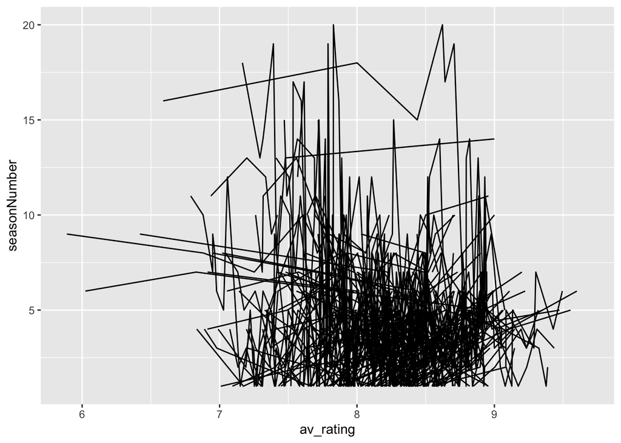

```r
ggplot(data = tv_long, mapping = aes(x = av_rating, y = seasonNumber, group = titleId)) + geom_line()
```

The data is all over the place, but typically shows ratings stay in roughly the same area for all seasons.

## Question 2

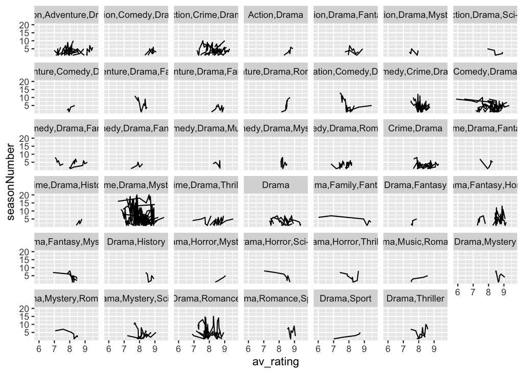

```r
ggplot(data = tv_long, mapping = aes(x = av_rating, y = seasonNumber, group = titleId)) + geom_line() +facet_wrap(~ genres )
```

```r
ggsave("tvdata.pdf")
```

Each genre has a similar average rating trend throughout its seasons.

//What shows tend to last longer? Do ratings change much across seasons? Can you identify that show on `Drama, Family, Fantasy` whose ratings just plummeted?

## Question 3

```r
tv_genres <- tv_ratings %>%
  filter(av_rating >= 9) %>%
arrange(desc(av_rating))
tv_genres
```

```
# A tibble: 93 × 7
   titleId   seasonNumber title                date       av_rating share genres
   <chr>            <dbl> <chr>                <date>         <dbl> <dbl> <chr>
 1 tt0098887            1 Parenthood           1990-11-13      9.68  1.68 Comed…
 2 tt0106028            6 Homicide: Life on t… 1997-12-05      9.6   0.13 Crime…
 3 tt0108968            5 Touched by an Angel  1998-11-15      9.6   0.08 Drama…
 4 tt0903747            5 Breaking Bad         2013-02-20      9.55 19.0  Crime…
 5 tt0944947            6 Game of Thrones      2016-05-25      9.49 15.2  Actio…
 6 tt3398228            5 BoJack Horseman      2018-09-14      9.47  0.45 Anima…
 7 tt0103352            3 Are You Afraid of t… 1994-02-23      9.43  2.6  Drama…
 8 tt0944947            4 Game of Thrones      2014-05-09      9.43 11.1  Actio…
 9 tt0976014            4 Greek                2011-03-07      9.4   0.01 Comed…
10 tt0090466            4 L.A. Law             1990-04-05      9.4   0.1  Drama
# ℹ 83 more rows
```

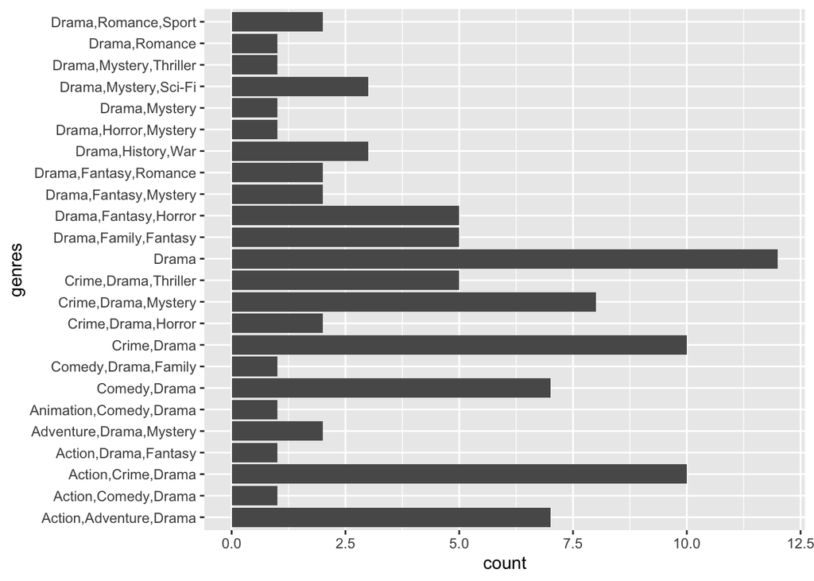

```r
ggplot(data = tv_genres, mapping = aes(x = genres)) + geom_bar() + coord_flip()
```

It flips the y and x-axis allowing more room for the genres to be listed.

Drama has the most top rated shows.

## Question 4

```r
comedies_dramas <- tv_ratings %>%
  mutate(is_comedy = if_else(str_detect(genres, "Comedy"),
                             1,
                             0)) %>% # If it contains the word comedy then 1, else 0
  filter(is_comedy == 1 | genres == "Drama") %>% # Keep comedies and dramas
  mutate(genres = if_else(genres == "Drama", # Make it so that we only have those two genres
                          "Drama",
                          "Comedy"))

glimpse(comedies_dramas)
```

```
Rows: 684
Columns: 8
$ titleId      <chr> "tt0312081", "tt0312081", "tt0312081", "tt1225901", "tt12…
$ seasonNumber <dbl> 1, 2, 3, 1, 2, 3, 4, 5, 1, 2, 1, 25, 1, 1, 2, 3, 4, 5, 1,…
$ title        <chr> "8 Simple Rules", "8 Simple Rules", "8 Simple Rules", "90…
$ date         <date> 2002-09-17, 2003-11-04, 2004-11-12, 2009-01-03, 2009-11-…
$ av_rating    <dbl> 7.5000, 8.6000, 8.4043, 7.1735, 7.4686, 7.6858, 6.8344, 7…
$ share        <dbl> 0.03, 0.10, 0.06, 0.40, 0.14, 0.10, 0.04, 0.01, 0.48, 0.4…
$ genres       <chr> "Comedy", "Comedy", "Comedy", "Comedy", "Comedy", "Comedy…
$ is_comedy    <dbl> 1, 1, 1, 1, 1, 1, 1, 1, 1, 1, 0, 1, 1, 1, 1, 1, 1, 1, 1, …
```

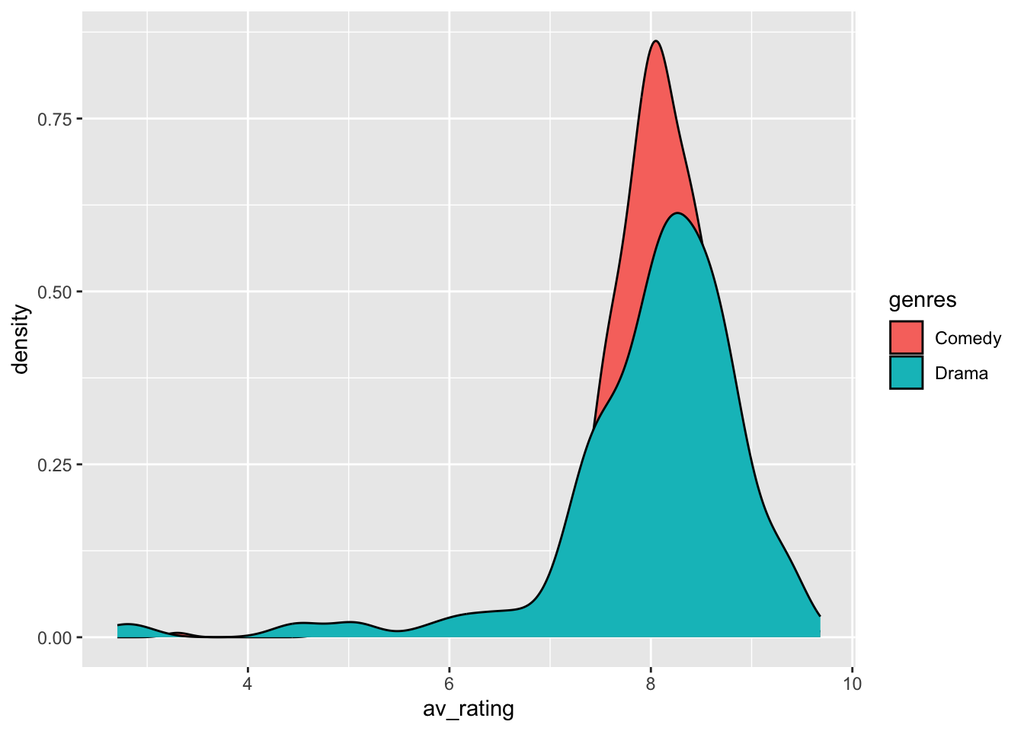

```r
ggplot(data = comedies_dramas, mapping = aes(x = av_rating, fill = genres)) + geom_density()
```

## Question 5

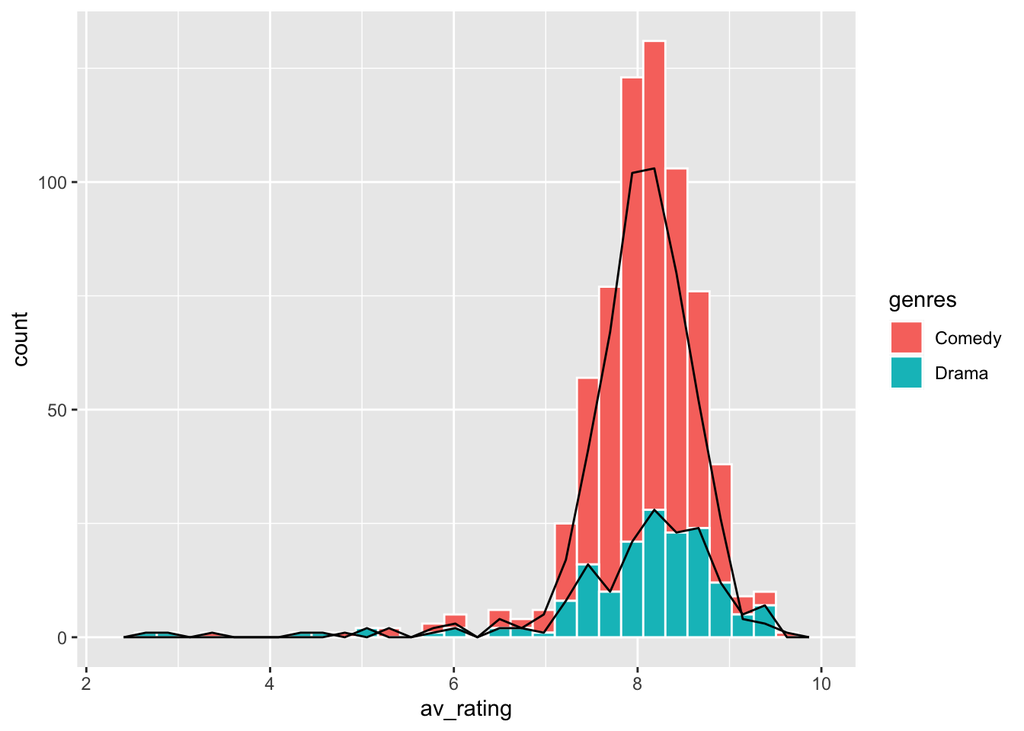

```r
ggplot(data = comedies_dramas, mapping = aes(x = av_rating, fill = genres)) + geom_histogram(color = "white") + geom_freqpoly()
```

## Question 6

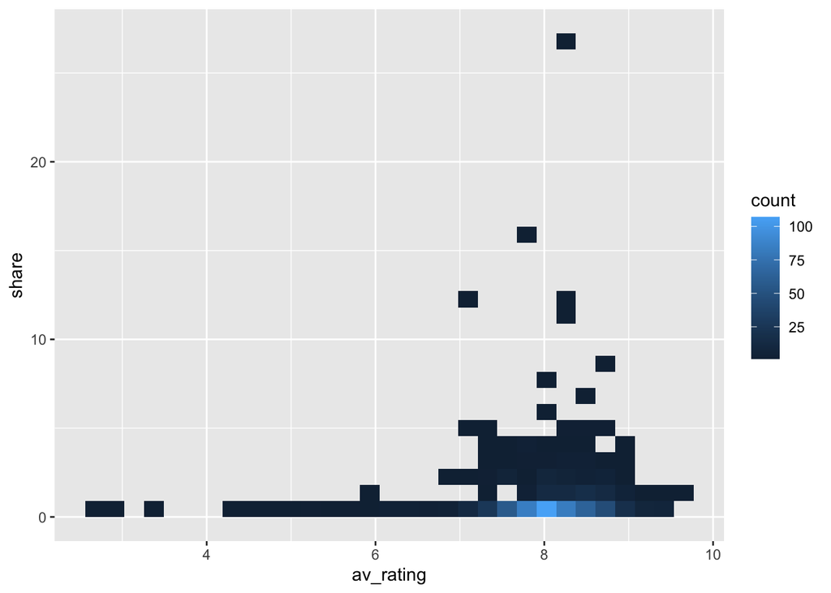

```r
ggplot(data = comedies_dramas, mapping = aes( x = av_rating, y = share)) +geom_bin_2d()
```

Thus shows how many had higher viewership while also seeing what the average rating was.

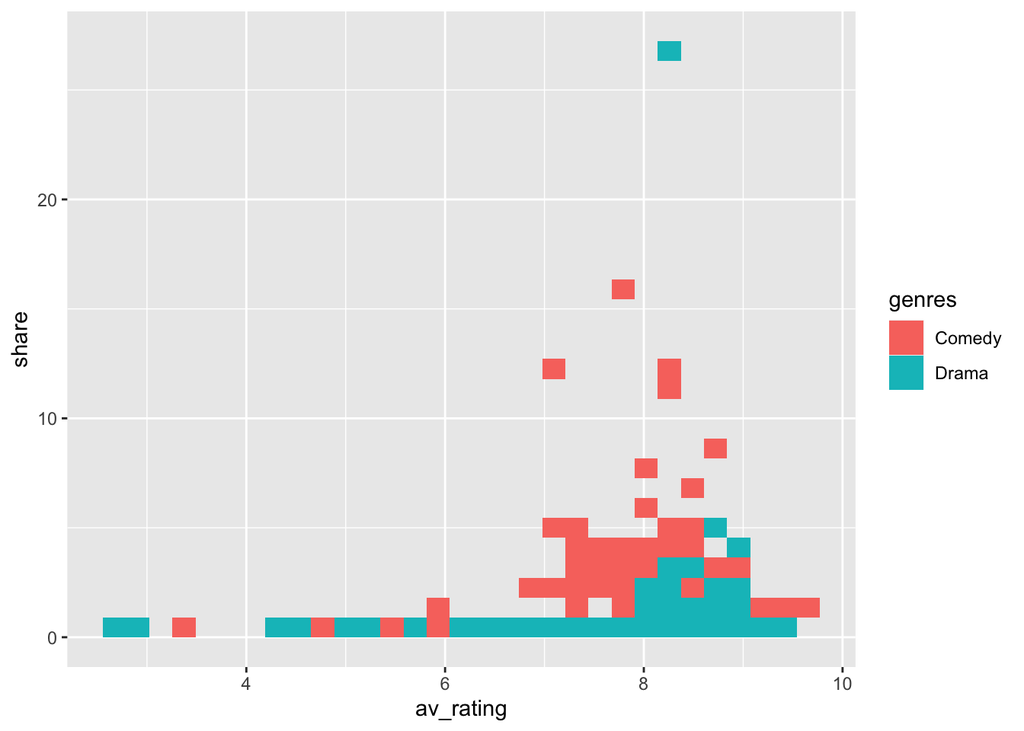

```r
ggplot(data = comedies_dramas, mapping = aes( x = av_rating, y = share, fill = genres)) +geom_bin_2d()
```

There are a lot of values around 8 and the fill aesthetic provides the colors to more easily distinguish the data. Dekalog is the outlier within the data because its share is around 27 and its average rating is around 8 which accurately represents the outlier.